# Predator_Conservation_EDA

Khadijah Amarah Moosa

2025-02-20

## Configuring knitr

```r
knitr::opts_chunk$set(echo = TRUE)
```

## Load essential R libraries

I loaded essential R libraries for data handling and visualization. I did this to ensure my necessary libraries are available for data processing and visualizing in my R session.

```r
library(dplyr)
```

```r
library(tidyr)
library(ggplot2)
```

## Load raw data into R for analysis

I read the csv file into R using the read.csv function. I did this to ensure that the raw data is loaded into R for analysis.

```r
raw_data <- read.csv("C:/Users/Student/Documents/GitHub Deliverable/predator_conservation/NonJournalRawDataIN.csv", sep = ",")
```

## Perform inital checks on imported dataset

I performed initial checks on the imported dataset. I did this to confirm that the dataset is corretly imported and to get an overview of its structure before further processing.

```r
# check top 5 rows to ensure data loaded correctly
head(raw_data, 5)
```

```
##                      Paper Journal..1..non.journal.0.   Study.design
## 1 Acorn and Dorrance 1994                           0   before-after
## 2 Agvaantseren et al. 2016                          0   before-after
## 3    Alexander et al. 2015                          1 control-impact
## 4          Ali et al. 2016                          1 control-impact
## 5          Ali et al. 2016                          1 control-impact
##                                   Predator.species
## 1                                           coyote
## 2                                     snow leopard
## 3 snow leopard, Eurasian lynx, wolf and brown bear
## 4                                        gray wolf
## 5                                        gray wolf
##                              Protected.assets Category.of.intervention
## 1                                       sheep                husbandry
## 2                        livestock in general  non-invasive management
## 3 sheep/goats, yak, horses, mules and donkeys                husbandry
## 4                      cattle and sheep/goats                husbandry
## 5                      cattle and sheep/goats                husbandry
##   Type.of.intervention Intervention.details  Country        Damage.metric
## 1       electric fence       electric fence   Canada      No. killed/farm
## 2    capacity building          handicrafts Mongolia No. predators killed
## 3              herding              herding    China % depredation events
## 4              herding              herding Pakistan             % losses
## 5     guarding animals        guarding dogs Pakistan             % losses
##   Relative.risk.RR
## 1        0.3988095
## 2        0.0000000
## 3        2.9565217
## 4        0.2295082
## 5        0.5573770
```

```r
# check column names to see if tidy
colnames(raw_data)
```

```
##  [1] "Paper"                      "Journal..1..non.journal.0."
##  [3] "Study.design"               "Predator.species"
##  [5] "Protected.assets"           "Category.of.intervention"
##  [7] "Type.of.intervention"       "Intervention.details"
##  [9] "Country"                    "Damage.metric"
## [11] "Relative.risk.RR"
```

## Tidy dataset

I tidied the dataset by renaming columns to more readable and consistent names. I did this to improve the readability of the data and to make subsequent analysis easier to work with.

```r
# rename columns
tidy_data <- raw_data %>%
  rename(
    Paper = `Paper`,
    Journal = `Journal..1..non.journal.0.`,  # Renaming for clarity
    Study_Design = `Study.design`,
    Predator_Species = `Predator.species`,
    Protected_Assets = `Protected.assets`,
    Intervention_Category = `Category.of.intervention`,
    Intervention_Type = `Type.of.intervention`,
    Intervention_Details = `Intervention.details`,
    Country = `Country`,
    Damage_Metric = `Damage.metric`,
    Relative_Risk_RR = `Relative.risk.RR`
  )

# view the renamed dataset
head(tidy_data)
```

```
##                      Paper Journal   Study_Design
## 1 Acorn and Dorrance 1994        0   before-after
## 2 Agvaantseren et al. 2016       0   before-after
## 3    Alexander et al. 2015       1 control-impact
## 4          Ali et al. 2016       1 control-impact
## 5          Ali et al. 2016       1 control-impact
## 6    Alldredge et al. 2015       1   before-after
##                                   Predator_Species
## 1                                           coyote
## 2                                     snow leopard
## 3 snow leopard, Eurasian lynx, wolf and brown bear
## 4                                        gray wolf
## 5                                        gray wolf
## 6                              American black bear
##                               Protected_Assets   Intervention_Category
```

[output cut: 20 more lines]

## Clean data and prepare for further analysis

I separated multiple values into different rows and I converted various columns to appropriate data types. I also checked to structure of the dataset after the transformations and confirmed the changes that I made to the column types. I did these steps to clean the data and prepare it for further analysis.

```r
# Separate multiple values into different rows
tidy_data <- tidy_data %>%
  separate_rows(Predator_Species, sep = ", ") %>%
  separate_rows(Protected_Assets, sep = ", ")

# View the transformed dataset
head(tidy_data)
```

```
## # A tibble: 6 × 11
##   Paper                   Journal Study_Design Predator_Species Protected_Assets
##   <chr>                     <int> <chr>        <chr>            <chr>
## 1 "Acorn and Dorrance 19…       0 before-after coyote           sheep
## 2 "Agvaantseren et al. 2…       0 before-after snow leopard     livestock in ge…
## 3 "Alexander et al. 2015"       1 control-imp… snow leopard     sheep/goats
## 4 "Alexander et al. 2015"       1 control-imp… snow leopard     yak
## 5 "Alexander et al. 2015"       1 control-imp… snow leopard     horses
## 6 "Alexander et al. 2015"       1 control-imp… snow leopard     mules and donke…
## # ℹ 6 more variables: Intervention_Category <chr>, Intervention_Type <chr>,
## #   Intervention_Details <chr>, Country <chr>, Damage_Metric <chr>,
## #   Relative_Risk_RR <dbl>
```

```r
# Convert column types
tidy_data <- tidy_data %>%
  mutate(
    Paper = as.character(Paper),  # Convert Paper names to character
    Journal = as.factor(Journal),  # Convert Journal column to factor (categorical)
    Study_Design = as.factor(Study_Design),  # Convert study design to factor
    Predator_Species = as.factor(Predator_Species),  # Convert predator species to factor
    Protected_Assets = as.factor(Protected_Assets),  # Convert protected assets to factor
    Intervention_Category = as.factor(Intervention_Category),  # Convert intervention category to factor
    Intervention_Type = as.factor(Intervention_Type),  # Convert intervention type to factor
    Intervention_Details = as.character(Intervention_Details),  # Keep as character
    Country = as.factor(Country),  # Convert country to factor
    Damage_Metric = as.character(Damage_Metric),  # Keep as character (might need more cleaning)
    Relative_Risk_RR = as.numeric(Relative_Risk_RR)  # Convert to numeric for calculations
  )

# Check structure of the updated dataset
str(tidy_data)
```

```
## tibble [601 × 11] (S3: tbl_df/tbl/data.frame)
##  $ Paper                : chr [1:601] "Acorn and Dorrance 1994 " "Agvaantseren et al. 2016" "Alexander et al. 2015" "Alexander et al. 2015" ...
##  $ Journal              : Factor w/ 2 levels "0","1": 1 1 2 2 2 2 2 2 2 2 ...
##  $ Study_Design         : Factor w/ 5 levels "BACI","before-after",..: 2 2 3 3 3 3 3 3 3 3 ...
##  $ Predator_Species     : Factor w/ 49 levels "African wild dog",..: 15 42 42 42 42 42 22 22 22 22 ...
##  $ Protected_Assets     : Factor w/ 70 levels "alpaca","apple orchard",..: 51 40 61 68 32 45 61 68 32 45 ...
##  $ Intervention_Category: Factor w/ 9 levels "aversion","husbandry",..: 2 9 2 2 2 2 2 2 2 2 ...
##  $ Intervention_Type    : Factor w/ 48 levels "acoustic and visual deterrents",..: 17 9 26 26 26 26 26 26 26 26 ...
##  $ Intervention_Details : chr [1:601] "electric fence" "handicrafts" "herding" "herding" ...
##  $ Country              : Factor w/ 51 levels "Afghanistan",..: 13 29 15 15 15 15 15 15 15 15 ...
##  $ Damage_Metric        : chr [1:601] "No. killed/farm" "No. predators killed" "% depredation events" "% depredation events" ...
##  $ Relative_Risk_RR     : num [1:601] 0.399 0 2.957 2.957 2.957 ...
```

## Create summary dataset and visualize relationship of the dataset

I created a summary dataset and visualized the relationship between Study Design and Relative Risk (RR), grouped by journal type. I created a scatter plot with error bars.

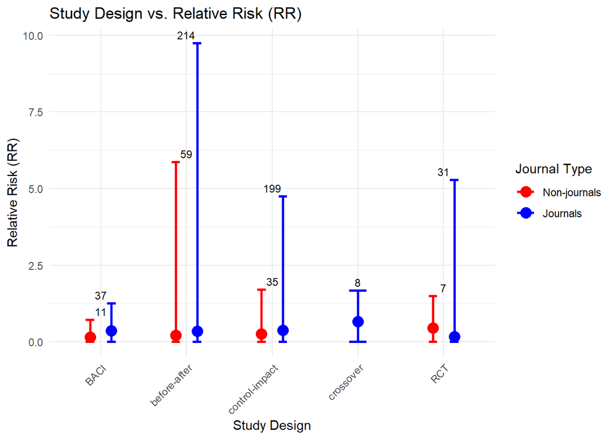

```r
summary_data <- tidy_data %>%
  group_by(Study_Design, Journal) %>%
  summarise(
    median_RR = median(Relative_Risk_RR),
    min_RR    = min(Relative_Risk_RR),
    max_RR    = max(Relative_Risk_RR),
    count     = n(),
    .groups   = "drop"
  )

ggplot(summary_data, aes(x = Study_Design, y = median_RR, color
                         = factor(Journal))) +
  geom_point(
    position = position_dodge(width = 0.5),
    size = 4
  ) +
  geom_errorbar(
    aes(ymin = min_RR, ymax = max_RR),
    position = position_dodge(width = 0.5),
    width = 0.2,
    size = 1
  ) +
  # ─────────────────────────────────────────────────────────────
  # Add text for count at the top of each error bar
  geom_text(
    aes(label = count, y = max_RR),             # Place label at max_RR
    position = position_dodge(width = 0.5),     # Same dodge
    vjust = -0.5,                               # Slightly above the error bar
    size = 3,                                   # Text size
    color = "black"                             # Text color (can also map to Journal)
  ) +
  # ─────────────────────────────────────────────────────────────
  scale_color_manual(
    values = c("red", "blue"),
    labels = c("Non-journals", "Journals")
  ) +
  labs(
    title = "Study Design vs. Relative Risk (RR)",
    x = "Study Design",
    y = "Relative Risk (RR)",
    color = "Journal Type"
  ) +
  theme_minimal() +
  theme(axis.text.x = element_text(angle = 45, hjust = 1))
```